# **Lab6 - Data Visualization**

## Introduction

At the end of this laboratory, you should be able to:

- manipulate data in order to make them suitable for particular charts
- make a bar/column chart using Python
- make a scatterplot using Python
- make a line chart using Python
- make a histogram using Python
- make a boxplot using Python

Reminder: you need to show your results / submit this jupyter file to have your lab credited.

Now, let us begin!

First, let us import the standard packages that we need. We might need to install some packages in python in our local drive as needed. However, this file was checked to work in Google Colab as of 2023-08-25.

```python
import pandas as pd
import numpy as np
import matplotlib.pyplot as plt
```

For any of the charts below, we must manipulate the data/dataframe/variable into the appropriate form.

For each case, we will demonstrate a very simple example of the chart using fake data, and then follow it up with using real data (and possibly use some transformation).

## Bar charts

### Simple example

Let us look at the following example, and examine the code after looking at the result.

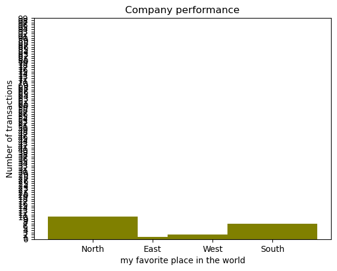

```python
labels=["North","East","West","South"]
yvals=[10,1,2,7]

nbars=max(yvals)
y=np.arange(100)

plt.bar(labels,yvals, color='olive', width=1.5)
plt.plot()

plt.xlabel("my favorite place in the world")
plt.yticks(ticks=y)
plt.ylabel("Number of transactions")
plt.title("Company performance")
plt.show()
```

This can be easily convered to a horizontal bar chart by using *.barh()* instead of *.bar()*.

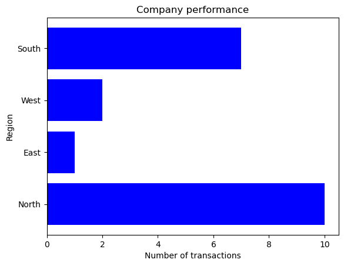

```python
labels=["North","East","West","South"]
yvals=[10,1,2,7]

nbars=len(labels)
y=np.arange(nbars)

plt.barh(labels,yvals, color='b')
plt.plot()

plt.ylabel("Region")
plt.yticks(ticks=y)
plt.xlabel("Number of transactions")
plt.title("Company performance")
plt.show()
```

### Real data

For our real data, let us use the data from the women's FIFA data for 2022 again. Let us first load the data.

Then, because we need 1 categorical variable and 1 numerical variable, we can choose, perhaps to plot the top 10 players (name=category) and their overall score.

```python
url = "https://github.com/emmanuelplan-hsb/hsb3119_data2023/raw/main/fifa2022_womens_full.csv"

df = pd.read_csv(url,encoding = 'unicode_escape')
df.head()
```

|  | sofifa_id | player_url | short_name | long_name | player_positions | overall | potential | value_eur | wage_eur | age | ... | lcb | cb | rcb | rb | gk | player_face_url | club_logo_url | club_flag_url | nation_logo_url | nation_flag_url |
| --- | --- | --- | --- | --- | --- | --- | --- | --- | --- | --- | --- | --- | --- | --- | --- | --- | --- | --- | --- | --- | --- |
| 0 | 227246 | https://sofifa.com/player/227246/lucy-bronze/2... | L. Bronze | Lucia Roberta Tough Bronze | RB, CM | 92 | 92 | NaN | NaN | 29 | ... | 87+3 | 87+3 | 87+3 | 88+3 | 21+3 | https://cdn.sofifa.com/players/227/246/22_120.png | NaN | NaN | https://cdn.sofifa.com/teams/113002/60.png | https://cdn.sofifa.com/flags/gb-eng.png |
| 1 | 227316 | https://sofifa.com/player/227316/wendie-renard... | W. Renard | Wéndèleine Thérèse Renard | CB | 92 | 92 | NaN | NaN | 30 | ... | 90+2 | 90+2 | 90+2 | 80+3 | 20+3 | https://cdn.sofifa.com/players/227/316/22_120.png | NaN | NaN | https://cdn.sofifa.com/teams/113003/60.png | https://cdn.sofifa.com/flags/fr.png |
| 2 | 233746 | https://sofifa.com/player/233746/vivianne-mied... | V. Miedema | Vivianne Miedema | ST | 92 | 93 | NaN | NaN | 24 | ... | 52+3 | 52+3 | 52+3 | 57+3 | 24+3 | https://cdn.sofifa.com/players/233/746/22_120.png | NaN | NaN | https://cdn.sofifa.com/teams/113011/60.png | https://cdn.sofifa.com/flags/nl.png |
| 3 | 227125 | https://sofifa.com/player/227125/samantha-kerr... | S. Kerr | Samantha May Kerr | ST, LW | 91 | 91 | NaN | NaN | 27 | ... | 56+3 | 56+3 | 56+3 | 60+3 | 20+3 | https://cdn.sofifa.com/players/227/125/22_120.png | NaN | NaN | https://cdn.sofifa.com/teams/112998/60.png | https://cdn.sofifa.com/flags/au.png |
| 4 | 226301 | https://sofifa.com/player/226301/alex-morgan/2... | A. Morgan | Alexandra Morgan Carrasco | ST | 90 | 90 | NaN | NaN | 31 | ... | 56+3 | 56+3 | 56+3 | 62+3 | 19+3 | https://cdn.sofifa.com/players/226/301/22_120.png | NaN | NaN | https://cdn.sofifa.com/teams/113009/60.png | https://cdn.sofifa.com/flags/us.png |

5 rows × 110 columns

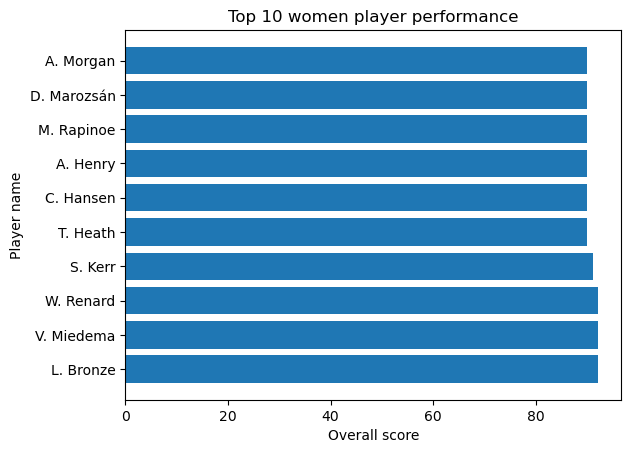

```python
df2=df[['short_name','overall']]
df3=df2.sort_values('overall',ascending=False)[0:10]

plt.barh(df3['short_name'],df3['overall'])
plt.plot()

plt.ylabel("Player name")
plt.xlabel("Overall score")
plt.title("Top 10 women player performance")
plt.show()

#Note: This isn't necessarily a good chart to make, because their marks are almost the same.
```

Your turn!

Make a bar/column chart using the nationality as the categorical variable and the average overall score of the players of that team. You will need to use *.groupby()*, *.mean()* and turn off the indices (because group by messes things around). That part of the code is provided.

```python
import pandas as pd

# Set pandas to display all columns
pd.set_option('display.max_columns', None)

# Display the first few rows to check the columns
print(df.head())
```

[output not shown]

[output cut: 166 more lines]

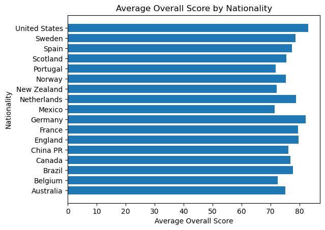

```python
# type your code here

# dfbar1=df[[...]]
# dfbar2=dfbar1.groupby('...',as_index=False).....

# plt.barh(dfbar2[...],dfbar2[...])
# plt.plot()

# plt.ylabel(...)
# plt.xlabel(...)
# plt.title(...)
# plt.show()

import pandas as pd
import matplotlib.pyplot as plt

# Group by nationality and calculate the average overall score
dfbar1 = df[['nationality_name', 'overall']]
dfbar2 = dfbar1.groupby('nationality_name', as_index=False).mean()

# Plot the average overall score by nationality
plt.barh(dfbar2['nationality_name'], dfbar2['overall'])
plt.ylabel("Nationality")
plt.xlabel("Average Overall Score")
plt.title("Average Overall Score by Nationality")
plt.show()
```

## Scatterplots

### Simple example

Scatterplots need two sets of numerical data: one for the $x$-axis and another for the $y$-axis. Note that like for bar charts, we can configure the color, shape, etc. or other characteristics of out chart.

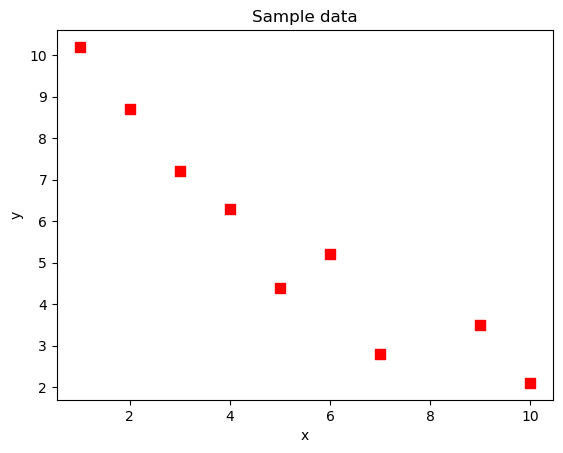

```python
x=np.array([1,2,3,4,5,6,7,9,10])
y=np.array([10.2, 8.7, 7.2, 6.3, 4.4, 5.2, 2.8, 3.5, 2.1])

plt.scatter(x, y, color='r', s=50, marker='s')

plt.ylabel("y")
plt.xlabel("x")
plt.title("Sample data")
plt.show()
```